# W07_DataManipulation

Seayoung Park

#### Midterm on Oct. 25th

- Check on e-Class 공지사항 (notice)
- submission: upload files to e-Class, **No late submission will be accepted.**
  - ~ 30 minutes late : 60% of the lowest score
  - 30 minutes ~ late : 0 point
- You can use any materials. (Open book, open note, open Google)
- You can discuss with your friends.
- **You **cannot** copy other’s work. That’s cheating and you will get ZERO.** (e.g., Even though, you solve a problem with your friend, each of you should type your own answer. Do not copy and paste. Not even partially like just changing few variable names. )
- Do not share exam questions outside of the class.
- e-Class 공지사항 확인
- 제출: 이클래스에 파일 업로드 . **늦은 제출은 미제출 처리됩니다.**
- 모든 자료 사용 가능합니다. (오픈북시험. 책, 필기, 구글 가능)
- 친구와 상의해도 됩니다.
- **다른사람이 작성한 것을 가져다 쓰는것은 안됩니다. 해당 경우, 부정행위로 간주되어 0점 처리됩니다.** (예를 들어, 친구와 같이 문제를 푼다 하더라고 답안은 각자 타이핑하여 작성해야 합니다. 복사 붙여넣기하지 마세요. 변수명만 바꾸는 정도로 약간 고치는 등 부분적인 복붙도 안됩니다.)
- 시험문제를 외부에 공유하지 마세요.

#### Dataset: 서울교통공사 역별 혼잡도 현황. 서울교통공사_역별시간대별혼잡도_20221231.csv

서울 열린데이터 광장, [**서울교통공사 역별 혼잡도 현황 click!**](http://data.seoul.go.kr/dataList/OA-12928/F/1/datasetView.do)

Data information:

- 서울교통공사에서 제공하는 1~8호선의 역별, 시간대별, 방향별 혼잡도 정보에 대한 서비스입니다.
- (단위 : %, 단위기준 : 열차 1량의 승차인원 = 160명 = 100%)

### 🟪 Read csv file from web link

- function to read a csv file is `read.csv("file path")`
- file path (url) must end with .csv

To try reading file from webpage link, we are reading file uploaded in [**THIS LINK**](https://github.com/czeropark/CAU23R/blob/main/SeoulMetro_congestion_20221231.csv)

[figure not shown]

This is our data. Click raw to get the link for the csv file.

[figure not shown]

Looks like the file is broken though… copy the link in the adress bar.

Now we have csv file url. “https://raw.githubusercontent.com/czeropark/CAU23R/main/SeoulMetro_congestion_20221231.csv”

Read the csv file, with `fileEncoding="cp949`

```r
metro_raw<- read.csv("https://raw.githubusercontent.com/czeropark/CAU23R/main/SeoulMetro_congestion_20221231.csv", fileEncoding="cp949", encoding="utf-8")
```

Let us check how the data looks like.

```r
head(metro_raw)
```

|  | 연번 | 요일구분 | 호선 | 역번호 | 출발역 | 상하구분 | X5시30분 | X6시00분 | X6시30분 | X7시00분 | X7시30분 | X8시00분 | X8시30분 | X9시00분 | X9시30분 | X10시00분 | X10시30분 | X11시00분 | X11시30분 | X12시00분 | X12시30분 | X13시00분 | X13시30분 | X14시00분 | X14시30분 | X15시00분 | X15시30분 | X16시00분 | X16시30분 | … |
| --- | --- | --- | --- | --- | --- | --- | --- | --- | --- | --- | --- | --- | --- | --- | --- | --- | --- | --- | --- | --- | --- | --- | --- | --- | --- | --- | --- | --- | --- | --- |
| 1 | 1 | 평일 | 1 | 150 | 서울역 | 상선 | 7.3 | 18.1 | 18.1 | 30.9 | 56.6 | 69.1 | 82.7 | 57.5 | 52.3 | 36.9 | 31.8 | 30.9 | 30.9 | 25.8 | 39.2 | 29.6 | 30.5 | 28.2 | 22.9 | 25.4 | 24.0 | 22.4 | 25.7 | … |
| 2 | 2 | 평일 | 1 | 150 | 서울역 | 하선 | 11.5 | 11.0 | 13.2 | 21.4 | 38.0 | 38.7 | 24.6 | 24.0 | 19.8 | 18.8 | 21.0 | 19.4 | 19.5 | 23.3 | 27.2 | 27.6 | 27.0 | 34.2 | 28.7 | 42.3 | 35.6 | 48.7 | 54.5 | … |
| 3 | 3 | 평일 | 1 | 151 | 시청 | 상선 | 6.6 | 15.4 | 14.7 | 25.0 | 42.4 | 55.0 | 56.0 | 44.3 | 48.2 | 30.5 | 29.8 | 29.2 | 28.6 | 26.2 | 36.6 | 30.8 | 29.1 | 28.6 | 25.3 | 27.4 | 24.6 | 24.3 | 28.3 | … |
| 4 | 4 | 평일 | 1 | 151 | 시청 | 하선 | 9.0 | 9.1 | 14.6 | 20.0 | 35.4 | 35.7 | 26.9 | 26.0 | 20.6 | 18.9 | 19.7 | 18.6 | 18.2 | 22.3 | 24.8 | 26.8 | 26.2 | 32.3 | 29.4 | 38.3 | 37.6 | 42.7 | 44.7 | … |
| 5 | 5 | 평일 | 1 | 152 | 종각 | 상선 | 6.3 | 14.4 | 10.7 | 17.6 | 26.7 | 36.0 | 31.2 | 28.0 | 36.5 | 27.4 | 24.8 | 26.4 | 26.4 | 25.9 | 31.8 | 29.6 | 28.9 | 30.2 | 26.6 | 30.1 | 27.8 | 28.0 | 30.4 | … |
| 6 | 6 | 평일 | 1 | 152 | 종각 | 하선 | 9.8 | 9.6 | 15.6 | 24.4 | 44.7 | 47.5 | 45.6 | 34.6 | 26.0 | 20.6 | 21.4 | 19.2 | 18.8 | 22.2 | 25.6 | 25.7 | 27.5 | 30.5 | 29.3 | 38.2 | 32.4 | 40.6 | 41.3 | … |

```r
str(metro_raw)
```

```
'data.frame':   1658 obs. of  45 variables:
 $ 연번     : int  1 2 3 4 5 6 7 8 9 10 ...
 $ 요일구분 : chr  "평일" "평일" "평일" "평일" ...
 $ 호선     : int  1 1 1 1 1 1 1 1 1 1 ...
 $ 역번호   : int  150 150 151 151 152 152 153 153 154 154 ...
 $ 출발역   : chr  "서울역" "서울역" "시청" "시청" ...
 $ 상하구분 : chr  "상선" "하선" "상선" "하선" ...
 $ X5시30분 : num  7.3 11.5 6.6 9 6.3 9.8 6.2 11.6 5.7 13.5 ...
 $ X6시00분 : num  18.1 11 15.4 9.1 14.4 9.6 13.8 9.1 12.8 9.8 ...
 $ X6시30분 : num  18.1 13.2 14.7 14.6 10.7 15.6 10.6 19.6 8.7 21.4 ...
 $ X7시00분 : num  30.9 21.4 25 20 17.6 24.4 17.2 28.7 13.1 34.6 ...
 $ X7시30분 : num  56.6 38 42.4 35.4 26.7 44.7 25.9 58.3 20.4 61.7 ...
 $ X8시00분 : num  69.1 38.7 55 35.7 36 47.5 40.7 61.2 31.4 72 ...
 $ X8시30분 : num  82.7 24.6 56 26.9 31.2 45.6 32.5 72 23.1 74.4 ...
 $ X9시00분 : num  57.5 24 44.3 26 28 34.6 28.7 48.9 24.1 56.3 ...
```

[output cut: 31 more lines]

### 🟪 Load packages

We are using `dplyr` and `tidyr` today.

```r
#install.packages('tidyr')
library(tidyr)
library(dplyr)
```

### 🟪 Change column names

`rename(dataframe, newname = oldname, ...)`

- `연번` **→** `no`
- `요일구분` **→** `day`
- `호선` **→** `line`
- `역번호` **→** `station_no`
- `출발역`**→** `station`
- `상하구분`**→** `direction`

```r
metro_renamed<- metro_raw %>% rename(no = 연번,
                                       day = 요일구분,
                                       line = 호선,
                                       station_no = 역번호,
                                       station = 출발역,
                                       direction = 상하구분)
str(metro_renamed)
```

```
'data.frame':   1658 obs. of  45 variables:
 $ no        : int  1 2 3 4 5 6 7 8 9 10 ...
 $ day       : chr  "평일" "평일" "평일" "평일" ...
 $ line      : int  1 1 1 1 1 1 1 1 1 1 ...
 $ station_no: int  150 150 151 151 152 152 153 153 154 154 ...
 $ station   : chr  "서울역" "서울역" "시청" "시청" ...
 $ direction : chr  "상선" "하선" "상선" "하선" ...
 $ X5시30분  : num  7.3 11.5 6.6 9 6.3 9.8 6.2 11.6 5.7 13.5 ...
 $ X6시00분  : num  18.1 11 15.4 9.1 14.4 9.6 13.8 9.1 12.8 9.8 ...
 $ X6시30분  : num  18.1 13.2 14.7 14.6 10.7 15.6 10.6 19.6 8.7 21.4 ...
 $ X7시00분  : num  30.9 21.4 25 20 17.6 24.4 17.2 28.7 13.1 34.6 ...
 $ X7시30분  : num  56.6 38 42.4 35.4 26.7 44.7 25.9 58.3 20.4 61.7 ...
 $ X8시00분  : num  69.1 38.7 55 35.7 36 47.5 40.7 61.2 31.4 72 ...
 $ X8시30분  : num  82.7 24.6 56 26.9 31.2 45.6 32.5 72 23.1 74.4 ...
 $ X9시00분  : num  57.5 24 44.3 26 28 34.6 28.7 48.9 24.1 56.3 ...
```

[output cut: 31 more lines]

### 🟪 Convert `line` and `station_no` values into character

- `as.numeric(vector)` change `vector` values into numeric
- `as.character(vector)` change `vector` values into character
- `as.factor(vector)` change `vector` values into factor

```r
metro_renamed$station_no <- as.character(metro_renamed$station_no)
metro_renamed$line <- as.character(metro_renamed$line)
str(metro_renamed)
```

```
'data.frame':   1658 obs. of  45 variables:
 $ no        : int  1 2 3 4 5 6 7 8 9 10 ...
 $ day       : chr  "평일" "평일" "평일" "평일" ...
 $ line      : chr  "1" "1" "1" "1" ...
 $ station_no: chr  "150" "150" "151" "151" ...
 $ station   : chr  "서울역" "서울역" "시청" "시청" ...
 $ direction : chr  "상선" "하선" "상선" "하선" ...
 $ X5시30분  : num  7.3 11.5 6.6 9 6.3 9.8 6.2 11.6 5.7 13.5 ...
 $ X6시00분  : num  18.1 11 15.4 9.1 14.4 9.6 13.8 9.1 12.8 9.8 ...
 $ X6시30분  : num  18.1 13.2 14.7 14.6 10.7 15.6 10.6 19.6 8.7 21.4 ...
 $ X7시00분  : num  30.9 21.4 25 20 17.6 24.4 17.2 28.7 13.1 34.6 ...
 $ X7시30분  : num  56.6 38 42.4 35.4 26.7 44.7 25.9 58.3 20.4 61.7 ...
 $ X8시00분  : num  69.1 38.7 55 35.7 36 47.5 40.7 61.2 31.4 72 ...
 $ X8시30분  : num  82.7 24.6 56 26.9 31.2 45.6 32.5 72 23.1 74.4 ...
 $ X9시00분  : num  57.5 24 44.3 26 28 34.6 28.7 48.9 24.1 56.3 ...
```

[output cut: 31 more lines]

### 🟪 Transform dataframe strucure

Now, we transform the shape of the table using `tidyr` package.

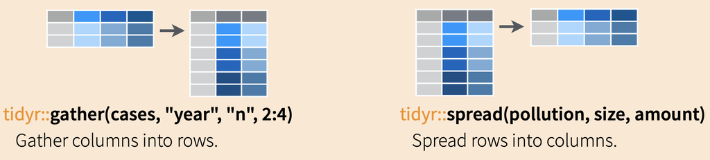

`gather()` changes table shape from:

| column x | time 1 | time 2 | time3 |
| --- | --- | --- | --- |
| row n vals | congestion n1 | congestion n2 | congestion n3 |

into:

| column x | time | congestion |
| --- | --- | --- |
| row n vals | time 1 | congestion n1 |
| row n vals | time 2 | congestion n2 |
| row n vals | time 3 | congestion n3 |

and `spread()` transform a table in the other way around.

```r
metro<- metro_renamed%>% gather(time, congestion, 7:45)
head(metro, 20)
```

|  | no | day | line | station_no | station | direction | time | congestion |
| --- | --- | --- | --- | --- | --- | --- | --- | --- |
| 1 | 1 | 평일 | 1 | 150 | 서울역 | 상선 | X5시30분 | 7.3 |
| 2 | 2 | 평일 | 1 | 150 | 서울역 | 하선 | X5시30분 | 11.5 |
| 3 | 3 | 평일 | 1 | 151 | 시청 | 상선 | X5시30분 | 6.6 |
| 4 | 4 | 평일 | 1 | 151 | 시청 | 하선 | X5시30분 | 9.0 |
| 5 | 5 | 평일 | 1 | 152 | 종각 | 상선 | X5시30분 | 6.3 |
| 6 | 6 | 평일 | 1 | 152 | 종각 | 하선 | X5시30분 | 9.8 |
| 7 | 7 | 평일 | 1 | 153 | 종로3가 | 상선 | X5시30분 | 6.2 |
| 8 | 8 | 평일 | 1 | 153 | 종로3가 | 하선 | X5시30분 | 11.6 |
| 9 | 9 | 평일 | 1 | 154 | 종로5가 | 상선 | X5시30분 | 5.7 |
| 10 | 10 | 평일 | 1 | 154 | 종로5가 | 하선 | X5시30분 | 13.5 |

[output cut: 10 more lines]

```r
metro2<- metro %>% spread(time, congestion)
head(metro2, 20)
```

|  | no | day | line | station_no | station | direction | X00시00분 | X00시30분 | X10시00분 | X10시30분 | X11시00분 | X11시30분 | X12시00분 | X12시30분 | X13시00분 | X13시30분 | X14시00분 | X14시30분 | X15시00분 | X15시30분 | X16시00분 | X16시30분 | X17시00분 | X17시30분 | X18시00분 | X18시30분 | X19시00분 | X19시30분 | X20시00분 | … |
| --- | --- | --- | --- | --- | --- | --- | --- | --- | --- | --- | --- | --- | --- | --- | --- | --- | --- | --- | --- | --- | --- | --- | --- | --- | --- | --- | --- | --- | --- | --- |
| 1 | 1 | 평일 | 1 | 150 | 서울역 | 상선 | 8.8 | 1.2 | 36.9 | 31.8 | 30.9 | 30.9 | 25.8 | 39.2 | 29.6 | 30.5 | 28.2 | 22.9 | 25.4 | 24.0 | 22.4 | 25.7 | 24.1 | 35.6 | 42.8 | 39.1 | 28.3 | 21.3 | 15.6 | … |
| 2 | 2 | 평일 | 1 | 150 | 서울역 | 하선 | 8.5 | 0.0 | 18.8 | 21.0 | 19.4 | 19.5 | 23.3 | 27.2 | 27.6 | 27.0 | 34.2 | 28.7 | 42.3 | 35.6 | 48.7 | 54.5 | 62.7 | 70.2 | 107.8 | 82.2 | 46.5 | 37.1 | 35.3 | … |
| 3 | 3 | 평일 | 1 | 151 | 시청 | 상선 | 7.0 | 2.8 | 30.5 | 29.8 | 29.2 | 28.6 | 26.2 | 36.6 | 30.8 | 29.1 | 28.6 | 25.3 | 27.4 | 24.6 | 24.3 | 28.3 | 26.5 | 39.2 | 58.1 | 47.5 | 33.2 | 24.7 | 19.1 | … |
| 4 | 4 | 평일 | 1 | 151 | 시청 | 하선 | 6.5 | 0.8 | 18.9 | 19.7 | 18.6 | 18.2 | 22.3 | 24.8 | 26.8 | 26.2 | 32.3 | 29.4 | 38.3 | 37.6 | 42.7 | 44.7 | 59.6 | 62.9 | 105.5 | 74.2 | 40.7 | 32.2 | 30.5 | … |
| 5 | 5 | 평일 | 1 | 152 | 종각 | 상선 | 9.6 | 4.2 | 27.4 | 24.8 | 26.4 | 26.4 | 25.9 | 31.8 | 29.6 | 28.9 | 30.2 | 26.6 | 30.1 | 27.8 | 28.0 | 30.4 | 33.7 | 41.8 | 76.1 | 54.9 | 39.6 | 28.9 | 26.8 | … |
| 6 | 6 | 평일 | 1 | 152 | 종각 | 하선 | 2.5 | 0.6 | 20.6 | 21.4 | 19.2 | 18.8 | 22.2 | 25.6 | 25.7 | 27.5 | 30.5 | 29.3 | 38.2 | 32.4 | 40.6 | 41.3 | 52.0 | 55.3 | 79.1 | 53.0 | 30.4 | 26.5 | 23.6 | … |
| 7 | 7 | 평일 | 1 | 153 | 종로3가 | 상선 | 10.0 | 4.7 | 28.4 | 27.3 | 25.8 | 26.1 | 27.4 | 35.2 | 35.1 | 28.8 | 33.4 | 30.8 | 33.9 | 33.9 | 30.9 | 35.4 | 37.8 | 46.6 | 81.1 | 67.7 | 40.5 | 32.2 | 28.9 | … |
| 8 | 8 | 평일 | 1 | 153 | 종로3가 | 하선 | 1.1 | 0.4 | 23.6 | 25.2 | 20.4 | 21.3 | 23.8 | 24.8 | 25.8 | 26.9 | 29.8 | 27.7 | 35.0 | 30.7 | 36.3 | 37.5 | 39.8 | 47.1 | 54.7 | 42.1 | 23.5 | 20.5 | 17.5 | … |
| 9 | 9 | 평일 | 1 | 154 | 종로5가 | 상선 | 9.7 | 4.6 | 24.9 | 21.8 | 22.2 | 22.6 | 26.7 | 28.0 | 32.8 | 25.5 | 32.7 | 29.9 | 35.4 | 31.8 | 31.1 | 36.5 | 35.8 | 50.8 | 83.8 | 72.1 | 44.6 | 32.5 | 30.7 | … |
| 10 | 10 | 평일 | 1 | 154 | 종로5가 | 하선 | 1.1 | 0.5 | 28.7 | 31.3 | 25.6 | 22.8 | 31.6 | 30.6 | 28.5 | 30.5 | 32.3 | 31.7 | 36.0 | 34.7 | 33.6 | 42.7 | 40.8 | 49.0 | 53.7 | 36.4 | 24.4 | 19.3 | 16.6 | … |

[output cut: 10 more lines]

### 🟪 Missing value, NA

Not all stations remain open for all time blocks. For example,

```r
tail(metro)
```

|  | no | day | line | station_no | station | direction | time | congestion |
| --- | --- | --- | --- | --- | --- | --- | --- | --- |
| 64657 | 1653 | 공휴일 | 8 | 2827 | 모란 | 상선 | X00시30분 | NA |
| 64658 | 1654 | 공휴일 | 8 | 2827 | 모란 | 하선 | X00시30분 | NA |
| 64659 | 1655 | 공휴일 | 8 | 2828 | 남위례 | 상선 | X00시30분 | NA |
| 64660 | 1656 | 공휴일 | 8 | 2828 | 남위례 | 하선 | X00시30분 | NA |
| 64661 | 1657 | 공휴일 | 8 | 2828 | 남위례 | 상선 | X00시30분 | NA |
| 64662 | 1658 | 공휴일 | 8 | 2828 | 남위례 | 하선 | X00시30분 | NA |

Let us see how many rows have no `congestion` values, using `is.na()` and `table()`

`is.na()`: is the value NA? → `TRUE` or `FALSE`. `table()`: frequency table on uniques values.

For example,

```r
vec1 <- c(5, 10, 15, NA, 25, 30)
is.na(vec1)
```

```
[1] FALSE FALSE FALSE  TRUE FALSE FALSE
```

`is.na(vec1)` has 2 unique values; `TRUE` and `FALSE`. Then, `table()` would count how many `TRUE` and `FALSE` values there are in `is.na(vec1)`

```r
is.na(vec1) %>% table()
```

```
.
FALSE  TRUE
    5     1
```

Now, let’s try how many `NA`s there are in `congestion` column in `metro`

```r
is.na(metro)%>%table()
```

```
.
 FALSE   TRUE
514678   2618
```

```r
is.na(metro$congestion)%>%table()
```

```
.
FALSE  TRUE
62044  2618
```

**What is the difference? What does the number 2618 mean? 2618 stations?**

### 🟪 Removing rows with at least one `NA`

`na.omit()`

```r
metro_omitted <- na.omit(metro)
metro_omitted%>%is.na()%>%table()
```

```
.
 FALSE
496352
```

### 🟪 Let’s find the most crowded station.

`slice_max(data, order_by= column, n= number of entries)` : select rows with the `n` largest values of the `column` (by group if grouped data).

```r
metro%>%slice_max(congestion, n=4)
```

| no | day | line | station_no | station | direction | time | congestion |
| --- | --- | --- | --- | --- | --- | --- | --- |
| 210 | 평일 | 4 | 418 | 성신여대입구 | 하선 | X8시00분 | 185.5 |
| 212 | 평일 | 4 | 419 | 한성대입구 | 하선 | X8시00분 | 184.5 |
| 208 | 평일 | 4 | 417 | 길음 | 하선 | X8시00분 | 176.2 |
| 72 | 평일 | 2 | 226 | 사당 | 외선 | X8시30분 | 172.3 |

```r
summary(metro$congestion)
```

```
   Min. 1st Qu.  Median    Mean 3rd Qu.    Max.    NA's
    0.0    13.0    24.1    26.8    36.2   185.5    2618
```

**What are the 3 most crowded stations on line 7?**

```r
metro %>% filter(line=="7") %>% slice_max(order_by = congestion, n=3)
```

| no | day | line | station_no | station | direction | time | congestion |
| --- | --- | --- | --- | --- | --- | --- | --- |
| 468 | 평일 | 7 | 2728 | 어린이대공원 | 하선 | X8시00분 | 160.6 |
| 464 | 평일 | 7 | 2726 | 중곡 | 하선 | X8시00분 | 160.4 |
| 466 | 평일 | 7 | 2727 | 군자 | 하선 | X8시00분 | 159.4 |

**What are the 3 most crowded stations for each line?**

```r
metro %>% group_by(line) %>% slice_max(order_by = congestion,n=3)
```

| no | day | line | station_no | station | direction | time | congestion |
| --- | --- | --- | --- | --- | --- | --- | --- |
| 2 | 평일 | 1 | 150 | 서울역 | 하선 | X18시00분 | 107.8 |
| 4 | 평일 | 1 | 151 | 시청 | 하선 | X18시00분 | 105.5 |
| 9 | 평일 | 1 | 154 | 종로5가 | 상선 | X18시00분 | 83.8 |
| 72 | 평일 | 2 | 226 | 사당 | 외선 | X8시30분 | 172.3 |
| 70 | 평일 | 2 | 225 | 방배 | 외선 | X8시30분 | 164.6 |
| 69 | 평일 | 2 | 225 | 방배 | 내선 | X18시30분 | 155.5 |
| 138 | 평일 | 3 | 316 | 독립문 | 하선 | X8시00분 | 154.8 |
| 136 | 평일 | 3 | 315 | 무악재 | 하선 | X8시00분 | 154.6 |
| 134 | 평일 | 3 | 314 | 홍제 | 하선 | X8시00분 | 153.8 |
| 210 | 평일 | 4 | 418 | 성신여대입구 | 하선 | X8시00분 | 185.5 |

[output cut: 14 more lines]

**What does the code below show?**

```r
metro_commute <- metro %>% filter(time=="X8시00분" | time=="X18시30분")
metro_commute_maxs <- metro_commute %>% group_by(line, time) %>%  slice_max(congestion, n=1)

metro_commute_maxs %>%
  summarise(maxCon_time_line = max(congestion), across()) %>%
  summarise(station, direction, time, congestion, ratio = congestion/sum(maxCon_time_line))
```

| line | station | direction | time | congestion | ratio |
| --- | --- | --- | --- | --- | --- |
| 1 | 서울역 | 하선 | X18시30분 | 82.2 | 0.5003043 |
| 1 | 동묘앞 | 하선 | X8시00분 | 82.1 | 0.4996957 |
| 2 | 방배 | 내선 | X18시30분 | 155.5 | 0.5235690 |
| 2 | 사당 | 외선 | X8시00분 | 141.5 | 0.4764310 |
| 3 | 경복궁 | 상선 | X18시30분 | 117.6 | 0.4317181 |
| 3 | 독립문 | 하선 | X8시00분 | 154.8 | 0.5682819 |
| 4 | 동대문 | 상선 | X18시30분 | 141.1 | 0.4320269 |
| 4 | 성신여대입구 | 하선 | X8시00분 | 185.5 | 0.5679731 |
| 5 | 길동 | 하선 | X18시30분 | 125.1 | 0.4703008 |
| 5 | 길동 | 상선 | X8시00분 | 140.9 | 0.5296992 |

[output cut: 6 more lines]

## 🟪 Issues in data preprocessing

Let’s print out rows of `구산` station.

```r
metro%>%filter(station=="구산")
```

| no | day | line | station_no | station | direction | time | congestion |
| --- | --- | --- | --- | --- | --- | --- | --- |
| 365 | 평일 | 6 | 2616 | 구산 | 상선 | X5시30분 | 0.0 |
| 366 | 평일 | 6 | 2616 | 구산 | 하선 | X5시30분 | 17.1 |
| 923 | 토요일 | 6 | 2616 | 구산 | 상선 | X5시30분 | NA |
| 924 | 토요일 | 6 | 2616 | 구산 | 하선 | X5시30분 | 10.5 |
| 1469 | 공휴일 | 6 | 2616 | 구산 | 상선 | X5시30분 | NA |
| 1470 | 공휴일 | 6 | 2616 | 구산 | 하선 | X5시30분 | 6.4 |
| 365 | 평일 | 6 | 2616 | 구산 | 상선 | X6시00분 | 0.0 |
| 366 | 평일 | 6 | 2616 | 구산 | 하선 | X6시00분 | 13.0 |
| 923 | 토요일 | 6 | 2616 | 구산 | 상선 | X6시00분 | NA |
| 924 | 토요일 | 6 | 2616 | 구산 | 하선 | X6시00분 | 8.4 |

[output cut: 224 more lines]

**Remove rows with `NA`?**

**What about now?**

```r
metro_renamed%>%filter(station=="구산")
```

| no | day | line | station_no | station | direction | X5시30분 | X6시00분 | X6시30분 | X7시00분 | X7시30분 | X8시00분 | X8시30분 | X9시00분 | X9시30분 | X10시00분 | X10시30분 | X11시00분 | X11시30분 | X12시00분 | X12시30분 | X13시00분 | X13시30분 | X14시00분 | X14시30분 | X15시00분 | X15시30분 | X16시00분 | X16시30분 | X17시00분 | … |
| --- | --- | --- | --- | --- | --- | --- | --- | --- | --- | --- | --- | --- | --- | --- | --- | --- | --- | --- | --- | --- | --- | --- | --- | --- | --- | --- | --- | --- | --- | --- |
| 365 | 평일 | 6 | 2616 | 구산 | 상선 | 0.0 | 0.0 | 0.0 | 0.0 | 0.0 | 0.0 | 0.0 | 0.0 | 0.0 | 0.0 | 0.0 | 0.0 | 0.0 | 0.0 | 0.0 | 0.0 | 0.0 | 0.0 | 0.0 | 0.0 | 0.0 | 0.0 | 0.0 | 0.0 | … |
| 366 | 평일 | 6 | 2616 | 구산 | 하선 | 17.1 | 13.0 | 19.9 | 31.5 | 40.3 | 46.5 | 29.1 | 22.9 | 21.0 | 19.4 | 17.8 | 17.0 | 16.4 | 18.5 | 18.1 | 17.0 | 17.1 | 16.0 | 15.5 | 18.0 | 18.1 | 22.3 | 25.7 | 23.2 | … |
| 923 | 토요일 | 6 | 2616 | 구산 | 상선 | NA | NA | NA | NA | NA | NA | NA | NA | NA | NA | NA | NA | NA | NA | NA | NA | NA | NA | NA | NA | NA | NA | NA | NA | … |
| 924 | 토요일 | 6 | 2616 | 구산 | 하선 | 10.5 | 8.4 | 7.9 | 10.7 | 13.0 | 17.1 | 17.8 | 20.6 | 20.4 | 21.4 | 21.3 | 22.4 | 23.9 | 24.5 | 25.8 | 25.7 | 24.0 | 26.5 | 23.8 | 25.0 | 26.1 | 26.6 | 29.5 | 29.4 | … |
| 1469 | 공휴일 | 6 | 2616 | 구산 | 상선 | NA | NA | NA | NA | NA | NA | NA | NA | NA | NA | NA | NA | NA | NA | NA | NA | NA | NA | NA | NA | NA | NA | NA | NA | … |
| 1470 | 공휴일 | 6 | 2616 | 구산 | 하선 | 6.4 | 4.8 | 4.8 | 5.9 | 7.3 | 9.6 | 11.8 | 14.9 | 16.9 | 19.8 | 17.1 | 15.5 | 15.2 | 18.0 | 18.6 | 20.0 | 18.6 | 19.3 | 19.3 | 19.4 | 18.5 | 18.0 | 21.1 | 18.5 | … |

Okay, maybe we need extra information. http://www.seoulmetro.co.kr/kr/cyberStation.do

**What do you think?**

Let’s see how many stations are in the data.

```r
metro$line %>% table() # correct????????????????????????? no
```

```
.
    1     2     3     4     5     6     7     8
 2340 11934  7956  6318 13104  9126  9828  4056
```

```r
for (x in unique(metro$line)){
  stnList <- metro%>% filter(line==x)
  stnList_unique<- unique(stnList$station)
  print(paste(x, length(stnList_unique)))
  print(stnList_unique)
}
```

```
[1] "1 10"
 [1] "서울역"  "시청"    "종각"    "종로3가" "종로5가" "동대문"  "신설동"  "제기동"
 [9] "청량리"  "동묘앞"
[1] "2 52"
 [1] "시청"               "을지로입구"         "을지로3가"          "을지로4가"
 [5] "동대문역사문화공원" "신당"               "상왕십리"           "왕십리"
 [9] "한양대"             "뚝섬"               "성수"               "건대입구"
[13] "구의"               "강변"               "잠실나루"           "잠실"
[17] "신천"               "종합운동장"         "삼성"               "선릉"
[21] "역삼"               "강남"               "교대"               "서초"
[25] "방배"               "사당"               "낙성대"             "서울대입구"
[29] "봉천"               "신림"               "신대방"             "구로디지털단지"
[33] "대림"               "신도림"             "문래"               "영등포구청"
[37] "당산"               "합정"               "홍대입구"           "신촌(지하)"
[41] "이대"               "아현"               "충정로"             "용답"
```

[output cut: 64 more lines]

**Hmmm??????**

#### **Numbers are values, but they have no meaning in and of themselves. Always be aware of what you want to know about and how you should tranlate the numbers**